# Bellabeat Case Study Using R

# **Process Phase**

**Importing CSV files, Cleaning and Manipulating Data with R Packages**

1.**Installing and Loading Packages**

```r
# Packages needed for data wrangling and visualizations
# install.packages("tidyverse")
# install.packages("Rmisc")
# install.packages("RColorBrewer")
# install.packages("wesanderson")
```

```r
# Libraries must be loaded "library()" in every new session.
library(tidyverse)
library(lubridate)
library(dplyr)
library(ggplot2)
library(tidyr)
library(skimr)
library(janitor)
library(scales)
library( Rmisc)
library(RColorBrewer)
library(wesanderson)
```

2.**Importing Files From [FitBit Fitness Tracker Data](https://www.kaggle.com/datasets/arashnic/fitbit)**

```r
daily_activity <- read_csv("Capstone_Project_Fitabase_Data/Fitabase Data 4.12.16-5.12.16/dailyActivity_merged.csv")

sleep_day <- read_csv("Capstone_Project_Fitabase_Data/Fitabase Data 4.12.16-5.12.16/sleepDay_merged.csv")

daily_calories <- read_csv("Capstone_Project_Fitabase_Data/Fitabase Data 4.12.16-5.12.16/dailyCalories_merged.csv")

weight_log_info <- weightLogInfo_merged <- read_csv("Capstone_Project_Fitabase_Data/Fitabase Data 4.12.16-5.12.16/weightLogInfo_merged.csv")
```

3.**Exploring our Datasets for data cleaning**

```r
# will give us a tibble and "colnames" the names of all of our columns.
head(daily_activity)
colnames(daily_activity)

head(sleep_day)
colnames(sleep_day)

head(daily_calories)
colnames(daily_calories)

head(weight_log_info)
colnames(weight_log_info)
```

```r
# Checking unique participants and if there are any duplicates
n_distinct(daily_activity$Id)
```

```
## [1] 33
```

```r
n_distinct(sleep_day$Id)
```

```
## [1] 24
```

```r
n_distinct(daily_calories$Id)
```

```
## [1] 33
```

```r
n_distinct(weight_log_info$Id)
```

```
## [1] 8
```

```r
# total number of rows
nrow(daily_activity)
```

```
## [1] 940
```

```r
nrow(sleep_day)
```

```
## [1] 413
```

```r
nrow(daily_calories)
```

```
## [1] 940
```

```r
nrow(weight_log_info)
```

```
## [1] 67
```

4.**What Needs To Be Cleaned** - After previewing our data, we noticed that our our clumns need to be reformatted, our data type needs to be change from character to date format and some of our data sets seem to have duplicates. Next, we will remove duplicates, use clean_names to have column names all in snake_format and handle any missing data as well as filtering the data that will be useful to our analysis using pipelines. After completing this we will validate our results.

```r
# Looking for any duplicates in the data
sum(duplicated(daily_activity))
```

```
## [1] 0
```

```r
sum(duplicated(sleep_day))
```

```
## [1] 3
```

```r
sum(duplicated(weight_log_info))
```

```
## [1] 0
```

```r
sum(duplicated(daily_calories))
```

```
## [1] 0
```

```r
# Removing 3 duplicates in sleep_day, and renaming it to sleep_day_dr, dr=(duplicates removed)

sleep_day_dr <- sleep_day %>% distinct()
```

```r
# Verifying if the duplicated values are removed
sum(duplicated(sleep_day_dr))
```

```
## [1] 0
```

```r
# Now we will change dates from characters to date format
daily_activity$ActivityDate <- mdy(daily_activity$ActivityDate)
sleep_day_dr$SleepDay <- mdy_hms(sleep_day_dr$SleepDay)
daily_calories$ActivityDay <- mdy(daily_calories$ActivityDay)
weight_log_info$Date <- mdy_hms(weight_log_info$Date)
```

```r
# Lets verify and validate our data type change
str(daily_activity)
str(sleep_day_dr)
str(daily_calories)
str(weight_log_info)
```

```r
# Lets make column names more understandable, and change column names to snake format
daily_activity <- daily_activity %>% clean_names()
sleep_day_dr <- sleep_day %>% clean_names()
daily_calories <- daily_calories %>% clean_names()
weight_log_info <- weight_log_info %>% clean_names()
```

```r
# Lets view our data's column names
colnames(daily_activity)
```

```
##  [1] "id"                         "activity_date"
##  [3] "total_steps"                "total_distance"
##  [5] "tracker_distance"           "logged_activities_distance"
##  [7] "very_active_distance"       "moderately_active_distance"
##  [9] "light_active_distance"      "sedentary_active_distance"
## [11] "very_active_minutes"        "fairly_active_minutes"
## [13] "lightly_active_minutes"     "sedentary_minutes"
## [15] "calories"
```

```r
colnames(sleep_day_dr)
```

```
## [1] "id"                   "sleep_day"            "total_sleep_records"
## [4] "total_minutes_asleep" "total_time_in_bed"
```

```r
colnames(daily_calories)
```

```
## [1] "id"           "activity_day" "calories"
```

```r
colnames(weight_log_info)
```

```
## [1] "id"               "date"             "weight_kg"        "weight_pounds"
## [5] "fat"              "bmi"              "is_manual_report" "log_id"
```

- **Continuing cleaning and then transitioning into data transformation of *daily_activity* by filtering and sorting data.**

```r
# lets explore logged_activities_distance and if we need this data
daily_activity %>%
select(logged_activities_distance)
```

```
## # A tibble: 940 × 1
##    logged_activities_distance
##                         <dbl>
##  1                          0
##  2                          0
##  3                          0
##  4                          0
##  5                          0
##  6                          0
##  7                          0
##  8                          0
##  9                          0
## 10                          0
## # … with 930 more rows
```

```r
sum(daily_activity$logged_activities_distance, na.rm = TRUE)
```

```
## [1] 101.6807
```

```r
# lets preview a filtered tibble to check if values are > than 0 and if they tell us something.
daily_activity %>%
select(logged_activities_distance) %>%
filter(logged_activities_distance > 0)
```

```
## # A tibble: 32 × 1
##    logged_activities_distance
##                         <dbl>
##  1                       1.96
##  2                       4.08
##  3                       2.79
##  4                       3.17
##  5                       4.87
##  6                       4.85
##  7                       3.29
##  8                       4.93
##  9                       4.94
## 10                       4.92
## # … with 22 more rows
```

```r
# Creating (mutating) a new column made from sum of active distances
daily_activity <- daily_activity %>%
    mutate(new_total_distances= very_active_distance + moderately_active_distance + light_active_distance + sedentary_active_distance+logged_activities_distance)

# Previewing and comparing new column with preexisting total_distance and tracker_distance
daily_activity %>%
    select(new_total_distances, total_distance,tracker_distance)
```

```
## # A tibble: 940 × 3
##    new_total_distances total_distance tracker_distance
##                  <dbl>          <dbl>            <dbl>
##  1                8.49           8.5              8.5
##  2                6.97           6.97             6.97
##  3                6.75           6.74             6.74
##  4                6.23           6.28             6.28
##  5                8.16           8.16             8.16
##  6                6.48           6.48             6.48
##  7                8.60           8.59             8.59
##  8                9.88           9.88             9.88
##  9                6.68           6.68             6.68
## 10                6.34           6.34             6.34
## # … with 930 more rows
```

```r
# renamed date and bmi and column names snake_style
weight_log_info <- weight_log_info %>%
  clean_names() %>%
  dplyr::rename(date_weight_recorded=date,body_mass_index=bmi)

colnames(weight_log_info)
```

```
## [1] "id"                   "date_weight_recorded" "weight_kg"
## [4] "weight_pounds"        "fat"                  "body_mass_index"
## [7] "is_manual_report"     "log_id"
```

- We also want to filter and mutate information we want from the weight data frame to perform individual analysis that can help us get other insights.

```r
# New variable of clean and filtered data
weight_log_info_clean <- weight_log_info %>%
  select(id,
         date_weight_recorded,
         weight_kg,
         body_mass_index,
         is_manual_report)

head(weight_log_info_clean)
```

```
## # A tibble: 6 × 5
##           id date_weight_recorded weight_kg body_mass_index is_manual_report
##        <dbl> <dttm>                   <dbl>           <dbl> <lgl>
## 1 1503960366 2016-05-02 23:59:59       52.6            22.6 TRUE
## 2 1503960366 2016-05-03 23:59:59       52.6            22.6 TRUE
## 3 1927972279 2016-04-13 01:08:52      134.             47.5 FALSE
## 4 2873212765 2016-04-21 23:59:59       56.7            21.5 TRUE
## 5 2873212765 2016-05-12 23:59:59       57.3            21.7 TRUE
## 6 4319703577 2016-04-17 23:59:59       72.4            27.5 TRUE
```

- We want to mutate a column with people on healthy BMI range and people on overweight BMI range

```r
# mutating two new columns with bmi info
weight_log_info_clean <- weight_log_info_clean %>%
  mutate(healthy_bmi= body_mass_index<=25.0) %>%
  mutate(overweight_bmi= body_mass_index >=25.0)
# testing code
head(weight_log_info_clean)
```

```
## # A tibble: 6 × 7
##           id date_weight_recorded weight_kg body_mass_index is_manual_report
##        <dbl> <dttm>                   <dbl>           <dbl> <lgl>
## 1 1503960366 2016-05-02 23:59:59       52.6            22.6 TRUE
## 2 1503960366 2016-05-03 23:59:59       52.6            22.6 TRUE
## 3 1927972279 2016-04-13 01:08:52      134.             47.5 FALSE
## 4 2873212765 2016-04-21 23:59:59       56.7            21.5 TRUE
## 5 2873212765 2016-05-12 23:59:59       57.3            21.7 TRUE
## 6 4319703577 2016-04-17 23:59:59       72.4            27.5 TRUE
## # … with 2 more variables: healthy_bmi <lgl>, overweight_bmi <lgl>
```

- Since only 8 participants recorded their weight, we will keep distinct “id” records code for individual analysis of those 8 participants in our Analysis Phase.

```r
# This returns all of our columns with distinct id
weight_log_info_clean %>%
  distinct(id,.keep_all = TRUE)
```

- We now want to explore and transform the **daily_calories** data to have plot-able data.

```r
# activity_day transformed to show the day of the week.
daily_calories$activity_day <- daily_calories$activity_day %>%
weekdays()
# testing code if transformation worked
daily_calories %>%
select(activity_day)
```

```
## # A tibble: 940 × 1
##    activity_day
##    <chr>
##  1 Tuesday
##  2 Wednesday
##  3 Thursday
##  4 Friday
##  5 Saturday
##  6 Sunday
##  7 Monday
##  8 Tuesday
##  9 Wednesday
## 10 Thursday
## # … with 930 more rows
```

- For our **sleep_day** data set we thought it would be more convenient for our analysis to have our recorded minutes at sleep and our recorded minutes in bed transformed to hours with minutes so it can be more understandable to our audience.

```r
# transforming both minute columns to hours for time in bed clarity
sleep_day_dr <- sleep_day_dr %>%
mutate(total_hours_asleep= total_minutes_asleep/60)%>%
mutate(total_hrs_in_bed= total_time_in_bed/60)
# Testing our code
sleep_day_dr %>%
select(total_hours_asleep,total_hrs_in_bed) %>%
round(digits=2)
```

```
## # A tibble: 413 × 2
##    total_hours_asleep total_hrs_in_bed
##                 <dbl>            <dbl>
##  1               5.45             5.77
##  2               6.4              6.78
##  3               6.87             7.37
##  4               5.67             6.12
##  5              11.7             11.9
##  6               5.07             5.33
##  7               6                6.28
##  8               5.42             6.07
##  9               6.02             6.4
## 10               7.17             7.48
## # … with 403 more rows
```

- Now that we have made some transformations to have a better understanding of our variables, we will end our cleaning and transforming phase by **removing** every single row from all four of our data sets that have **NA’s** in order to have concise data for our analysis. After that we will identify our data’s variables names with the name “_cleaned”.

```r
# Removing Na's from our data for final cleaning stage
daily_activity_cleaned <- daily_activity %>%
drop_na()
sleep_day_cleaned <- sleep_day_dr %>%
  drop_na()
daily_calories_cleaned <- daily_calories %>%
drop_na()
weight_log_info_cleaned <- weight_log_info %>%
drop_na()

daily_activity_cleaned

sleep_day_cleaned

daily_calories_cleaned

weight_log_info_cleaned
```

## **Analyse Phase**

In this analyse phase we will start by looking at some basic statistics to have an in-depth understanding of our data. Lets remember that our main objective is to analyse a non-Bellabeat smart device (FitBit data) by examining trends and central tendencies which will guide us to bring our Bellabeat products to an optimal yet more consumable place in the industry. To do this we will also preview data visualizations with our concise and transformed data through which we will be able to have more clarity of what our data is telling us and drive the marketing team to greater business decisions.

- **Understanding some summary statistics**

```
##   total_steps    new_total_distances sedentary_minutes
##  Min.   :    0   Min.   : 0.000      Min.   :   0.0
##  1st Qu.: 3790   1st Qu.: 2.540      1st Qu.: 729.8
##  Median : 7406   Median : 5.190      Median :1057.5
##  Mean   : 7638   Mean   : 5.521      Mean   : 991.2
##  3rd Qu.:10727   3rd Qu.: 7.720      3rd Qu.:1229.5
##  Max.   :36019   Max.   :28.040      Max.   :1440.0
```

```
##  total_sleep_records total_hours_asleep total_hrs_in_bed
##  Min.   :1.000       Min.   : 0.9667    Min.   : 1.017
##  1st Qu.:1.000       1st Qu.: 6.0167    1st Qu.: 6.717
##  Median :1.000       Median : 7.2167    Median : 7.717
##  Mean   :1.119       Mean   : 6.9911    Mean   : 7.644
##  3rd Qu.:1.000       3rd Qu.: 8.1667    3rd Qu.: 8.767
##  Max.   :3.000       Max.   :13.2667    Max.   :16.017
```

```
##    weight_kg          fat        body_mass_index
##  Min.   :52.60   Min.   :22.00   Min.   :22.65
##  1st Qu.:57.55   1st Qu.:22.75   1st Qu.:23.85
##  Median :62.50   Median :23.50   Median :25.05
##  Mean   :62.50   Mean   :23.50   Mean   :25.05
##  3rd Qu.:67.45   3rd Qu.:24.25   3rd Qu.:26.25
##  Max.   :72.40   Max.   :25.00   Max.   :27.45
```

**Some useful insights gathered from our summary:**

- The average total steps that were taken daily were 7,638 that is around 5.5 miles walked, which happens to be our mean total distance.
- You can see that many of our participants recorded a significant amount of sedentary minutes, on average 991 minutes, this is definitely not helpful if the objective is to exercise and burn calories.
- Also lets keep in mind that these statistics are descriptive of our given data and cannot be representative of all smart device user population, but as a sample can still give us some good insights for recommendations.

*After having a look at summarized statistics of our data, we will create some bar graphs, histograms and scatter plots to analyse the behavior of our data and then merge data in order to see if there is any relationships or correlations with our different variables. Having visualizations helps us understand and view our data with a better understanding and get valuable insights with promising leads that we can later use and apply in our own Bellabeat products to make the best recommendations.*

- **Analyzing with Data Visualizations**

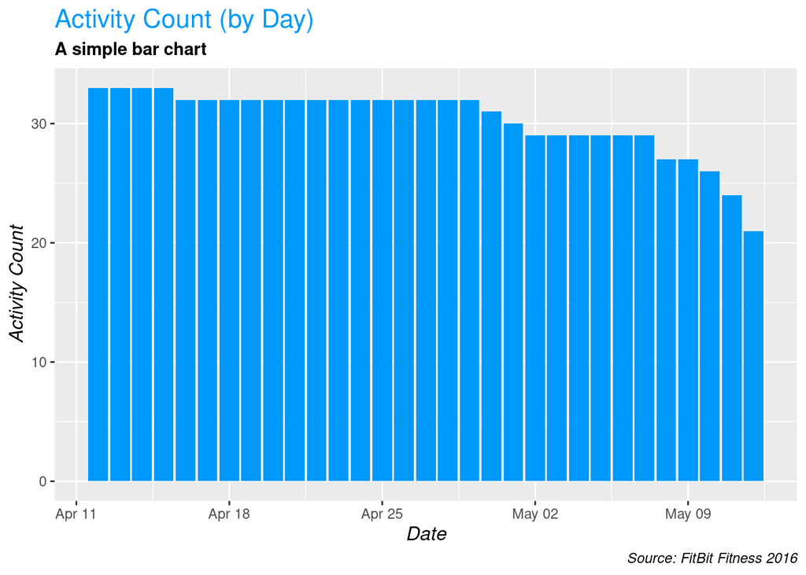

```r
# Data distribution Histogram
  Activities_graph_1 %>%
  ggplot()+ aes(x=activity_date, y= activities_per_day) + geom_col(fill = "#0099f9") +
  labs(title = "Activity Count (by Day)",subtitle = "A simple bar chart", caption = "Source: FitBit Fitness 2016", x="Date", y="Activity Count" )+
  theme(
    plot.title = element_text(color = "#0099f9", size = 16),
    plot.subtitle = element_text(face = "bold"),
    plot.caption = element_text(face = "italic")
  ) +

  theme(
    axis.title.x = element_text(size = 12, face = "italic"),
    axis.title.y = element_text(size = 12, face = "italic")
  )
```

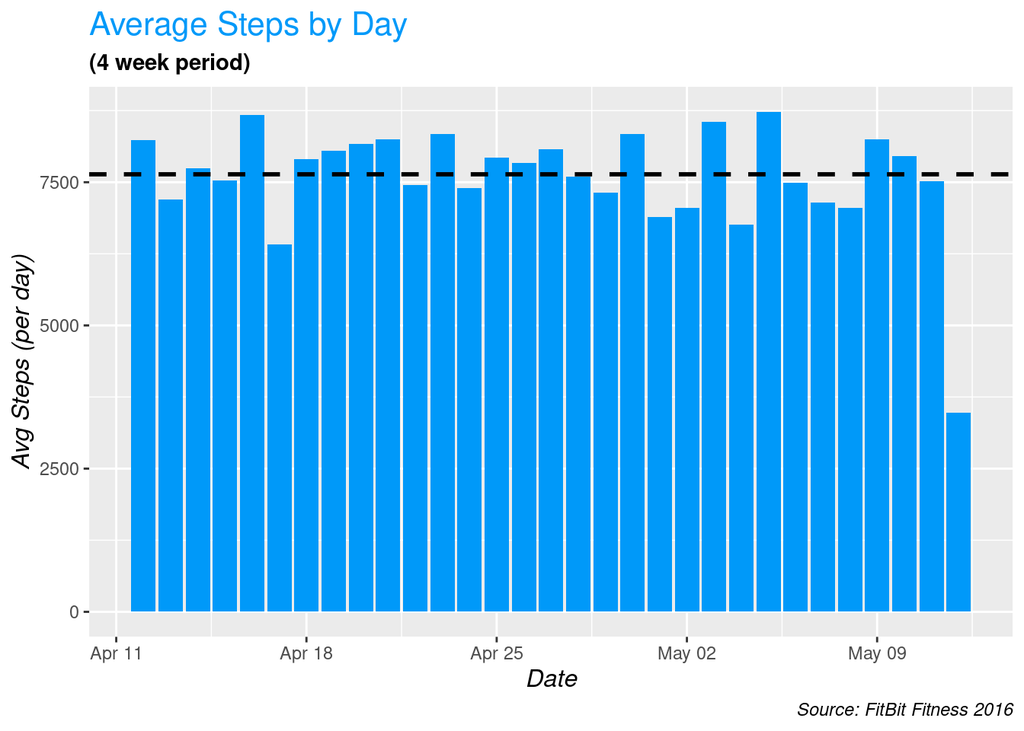

```r
# A.S (Average Steps summarised)
 A.S <- daily_activity_cleaned %>%
  group_by(activity_date) %>%
  dplyr::summarise(mean_steps_daily= mean(total_steps)) %>%
   ggplot()+ aes(x=activity_date, y=mean_steps_daily) + geom_col(fill = "#0099f9") +
  labs(title = "Average Steps by Day", subtitle = "(4 week period)", caption = "Source: FitBit Fitness 2016", x="Date", y="Avg Steps (per day)" )+
    theme(
    plot.title = element_text(color = "#0099f9", size = 16),
    plot.subtitle = element_text(face = "bold"),
    plot.caption = element_text(face = "italic")
  ) +

  theme(
    axis.title.x = element_text(size = 12, face = "italic"),
    axis.title.y = element_text(size = 12, face = "italic")
  )

A.S+
  geom_hline(yintercept = mean(daily_activity_cleaned$total_steps), linetype = "dashed", size = 1)
```

**In this graph we can see an average of all steps taken in our four weeks, this gives us an insight of which days our participants performed better by taking more steps than the average (represented by a line), of course if this were a competition or performance based experiment. It is interesting to note that there are several days where the user took significantly more steps than the average, as well as several days where the user took significantly fewer steps than the average.**

**This could suggest that the user’s activity level varied significantly day-to-day, and that they were not consistently meeting their daily step goals. It could also suggest that the user was engaging in more intense physical activity on certain days (resulting in higher step counts), and taking more rest days on others (resulting in lower step counts). For our Bellabeat product analysis is also a great way to analyze any peaks throughout our 4 week of tracking, one peak can clearly be seen at the end of the first week.**

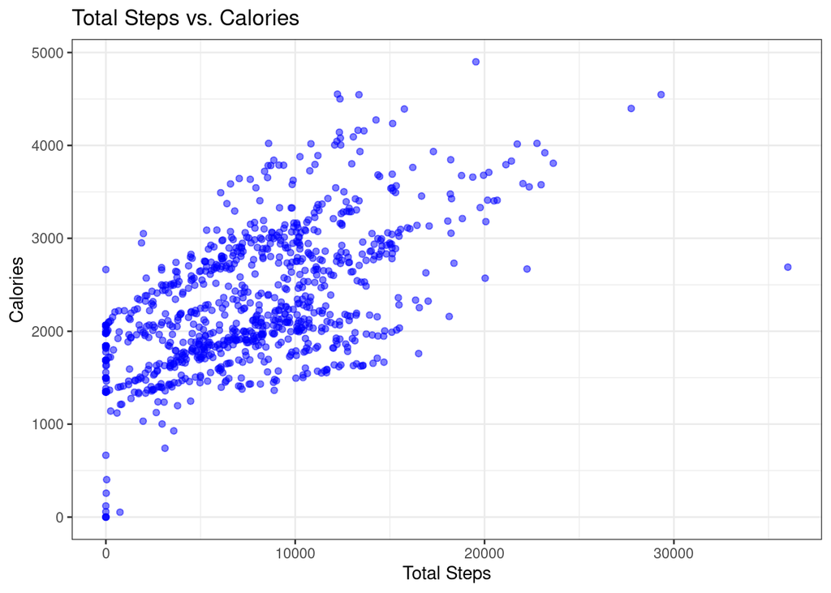

```r
ggplot(data = daily_activity_cleaned, aes(x = total_steps, y = calories)) +
  geom_point(color = "blue", alpha = 0.5) +
  labs(title = "Total Steps vs. Calories", x = "Total Steps", y = "Calories") +
  theme_bw()
```

**The scatterplot shows that there is a positive relationship between the two variables, meaning that as the number of steps taken increases, the number of calories burned also increases. The blue dots represent individual data points, while the transparency of the dots indicates the density of the data points in that area. This graph could be useful for people who are interested in tracking their physical activity and the corresponding number of calories burned. It could also be used to understsand the relationship between physical activity and energy expenditure. It makes sense to infer that as physical activity and exercise increase the number of calories burned also does. However, it is worth noting that the relationship does not appear to be entirely linear, with a greater spread of data points at higher step counts. This suggests that other factors, such as the intensity or duration of activity, may also play a role in the number of calories burned**

- **Continuing Observing Relationships and Correlations Between Variables with Scatter Plots**

1.**Fisrt we will analyze the relationship between Calories burned and other variables to see what affects calories burning the most.**

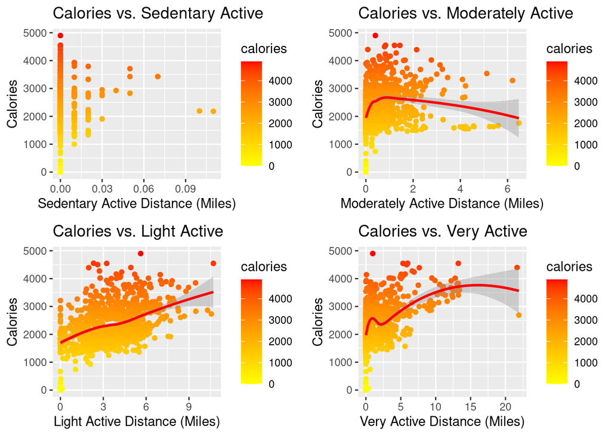

```r
# Creating multiplot to show relationship of calories with distance variables
gb <- daily_activity_cleaned %>%
 select(new_total_distances,calories,total_steps,very_active_distance,moderately_active_distance,light_active_distance,sedentary_active_distance)


sp <- gb %>%
  ggplot()+aes(x=sedentary_active_distance,y=calories,color=calories)+geom_point()+
  geom_smooth(color="red")+ labs(title = "Calories vs. Sedentary Active", x= "Sedentary Active Distance (Miles)", y= "Calories")+
  scale_colour_gradient(low = "yellow", high = "red", na.value = NA)

lp <- gb %>%
  ggplot()+aes(x=light_active_distance,y=calories,color=calories)+geom_point()+
  geom_smooth(color="red")+ labs(title = "Calories vs. Light Active", x= "Light Active Distance (Miles)", y= "Calories")+
  scale_colour_gradient(low = "yellow", high = "red", na.value = NA)

mp <- gb %>%
  ggplot()+aes(x= moderately_active_distance, y=calories,color=calories)+ geom_point()+
  geom_smooth(color="red")+ labs(title = "Calories vs. Moderately Active ", x= "Moderately Active Distance (Miles)", y= "Calories")+
  scale_colour_gradient(low = "yellow", high = "red", na.value = NA)

vp <- gb %>%
  ggplot()+aes(x= very_active_distance, y=calories,color=calories)+ geom_point()+
  geom_smooth(color="red")+ labs(title = "Calories vs. Very Active ", x= "Very Active Distance (Miles)", y= "Calories")+
  scale_colour_gradient(low = "yellow", high = "red", na.value = NA)

multiplot(sp,lp,mp,vp,cols = 2)
```

*Continuing observing Calories data this time including the daily_calories_cleaned data set*

```r
# understanding relationship between active distance and calories
active_calories_mean <- combined_data %>% group_by(activity_date,id) %>% drop_na() %>%
  dplyr::summarise(mean_act_distance=mean(new_total_distances),mean_calories=mean(calories))
```

```r
#preview our transformed data for plotting
head(active_calories_mean)
```

```
## # A tibble: 6 × 4
## # Groups:   activity_date [1]
##   activity_date         id mean_act_distance mean_calories
##   <date>             <dbl>             <dbl>         <dbl>
## 1 2016-04-12    1503960366             8.49           1985
## 2 2016-04-12    1644430081             7.77           3199
## 3 2016-04-12    1844505072             4.43           2030
## 4 2016-04-12    1927972279             0.470          2220
## 5 2016-04-12    2026352035             2.74           1459
## 6 2016-04-12    2320127002             7.49           2124
```

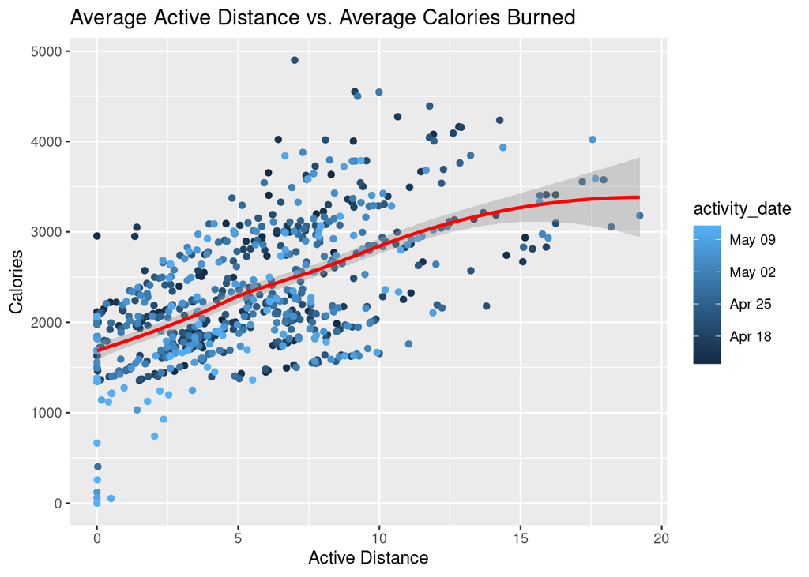

```r
# Scatter Plot with Positive Correlation
ggplot(active_calories_mean,aes(x=mean_act_distance,y=mean_calories))+ geom_point(aes(color=activity_date))+ geom_smooth(color="red") + labs(title = "Average Active Distance vs. Average Calories Burned", x= "Active Distance",y= "Calories")
```

**We can see that there is positive correlation between the average distance exercised and the average calories burned overall. We can safely assume that the more distance our participants walked or jogged, the more calories they burned. This is just helping us confirm our previous insights with our multiplots**

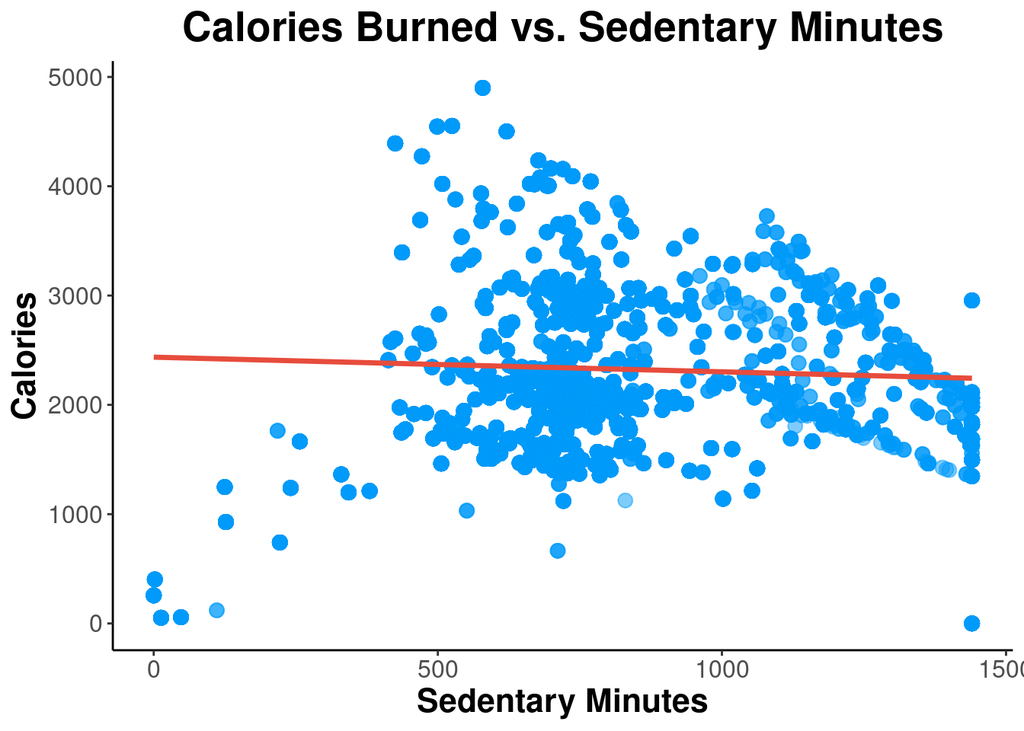

```r
# Understanding relationship between calories vs sedentary minutes
 P <- combined_data

# Set theme
theme_set(theme_classic())

# Plot the graph
P %>% ggplot(aes(x = sedentary_minutes, y = calories)) +
  geom_point(color = "#0099f9", alpha = 0.5, size = 3) +
  geom_smooth(color = "#e74c3c", size = 1.2, method = "lm", se = FALSE) +
  labs(title = "Calories Burned vs. Sedentary Minutes", x = "Sedentary Minutes", y = "Calories") +
  theme(plot.title = element_text(size = 20, face = "bold", hjust = 0.5),
        plot.subtitle = element_text(size = 16, face = "italic", hjust = 0.5),
        axis.title = element_text(size = 16, face = "bold"),
        axis.text = element_text(size = 12),
        legend.position = "none")
```

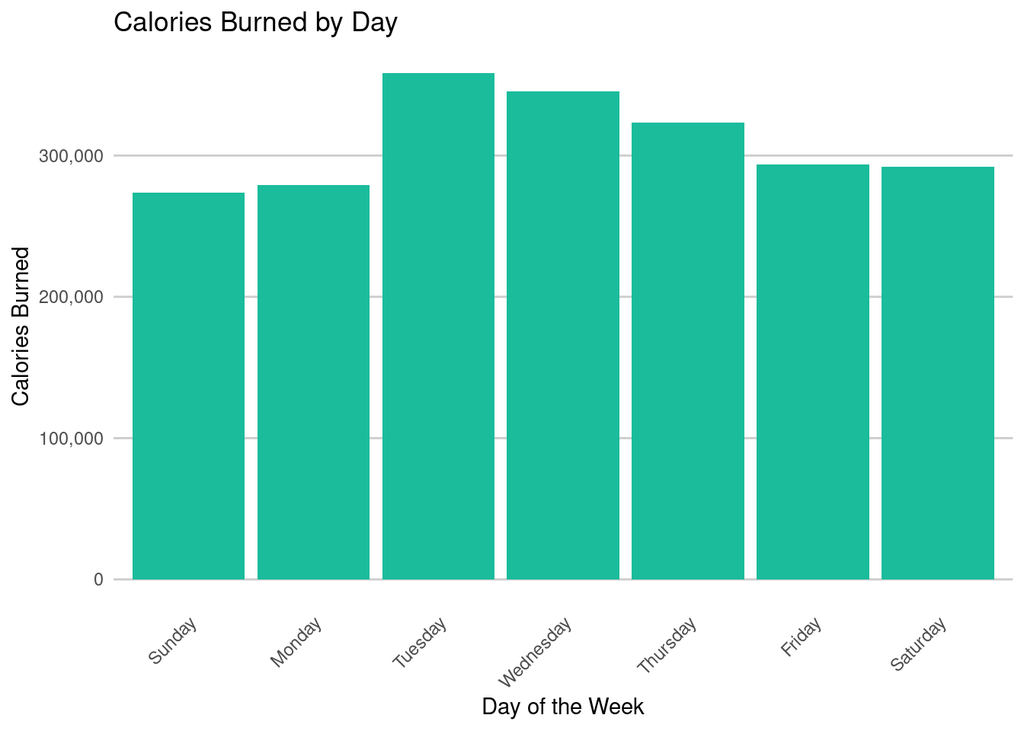

```r
# #Bar chart showing total calories burned for each day of the week
calories_by_day <- ggplot(data = daily_calories_cleaned, aes(x = factor(activity_day, levels = c("Sunday", "Monday", "Tuesday", "Wednesday", "Thursday", "Friday", "Saturday")), y = calories)) +
  geom_bar(stat = "identity", fill = "#1ABC9C") +
  labs(title = "Calories Burned by Day", x = "Day of the Week", y = "Calories Burned") +
  theme_minimal() +
  scale_y_continuous(labels = scales::comma) +
  theme(axis.text.x = element_text(angle = 45, hjust = 1), panel.grid.major.x = element_blank(),
        panel.grid.minor.y = element_blank(), panel.grid.major.y = element_line(colour = "gray80"))

calories_by_day
```

2.**Analyzing relationship between time *Asleep* and other variables**

**Lets analyze the relationship between total_steps vs. total_hours_asleep, and check if there is correlation, if taking more steps is linear to sleeping more.**

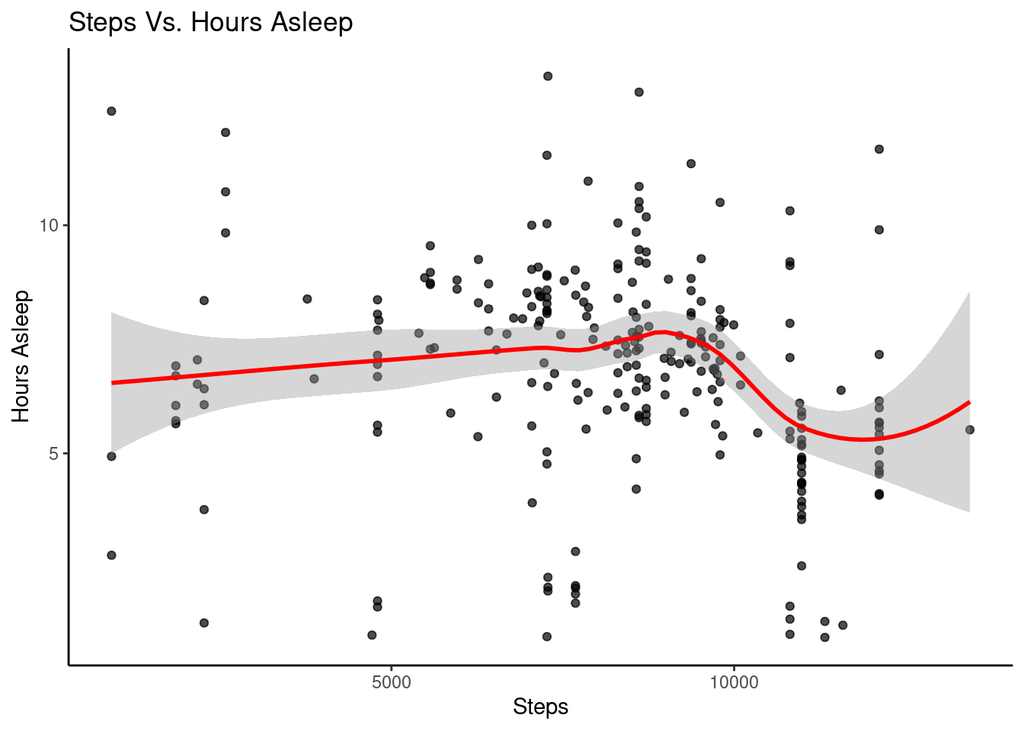

```r
# plotting hours asleep with total steps using merged data
  P %>%
  group_by(total_hours_asleep) %>%
  dplyr::summarise(mean_total_steps=mean(total_steps),mean_total_hours_asleep=mean(total_hours_asleep))%>%
  ggplot(aes(x=mean_total_steps,y=mean_total_hours_asleep))+ geom_point(alpha=0.7)+ geom_smooth(color="red")+ labs(title= "Steps Vs. Hours Asleep", x= "Steps", y="Hours Asleep" )
```

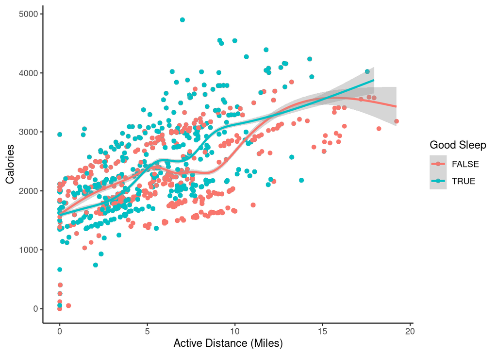

```r
# hours asleep vs. sedentary minutes
  P.2 <- merge(sleep_day_cleaned,daily_activity_cleaned,by="id")

  P.2 <- P.2 %>%
    mutate(good_sleep= total_hours_asleep>=7) %>%
    mutate(bad_sleep= total_hours_asleep<7)

  P.2 %>%
  ggplot()+aes(new_total_distances ,calories,color=good_sleep)+geom_point()+geom_smooth()+ labs(x="Active Distance (Miles)", y="Calories",color="Good Sleep")
```

**In this graph we can have a superior view of the positive correlation between more activity and calories burned complemented by the type of sleep our participants had, good sleep is determined by 7 hours or more of sleep, if not, it is considered bad sleep according to the [NIH](https://www.nhlbi.nih.gov/health/sleep/how-much-sleep#:~:text=Experts%20recommend%20that%20adults%20sleep,or%20more%20hours%20a%20night.) (National Heart, Lung, And Blood Institute). We can see that there is a more positive association with having a good night rest and burning more calories. We can also make assumptions (infer) such as that going further in distance does not necessarily give you more calories burned and that perhaps a better night sleep, more energy, and high intensity work out and intentional activity in shorter distances can make you burn more calories and obtain better results.**

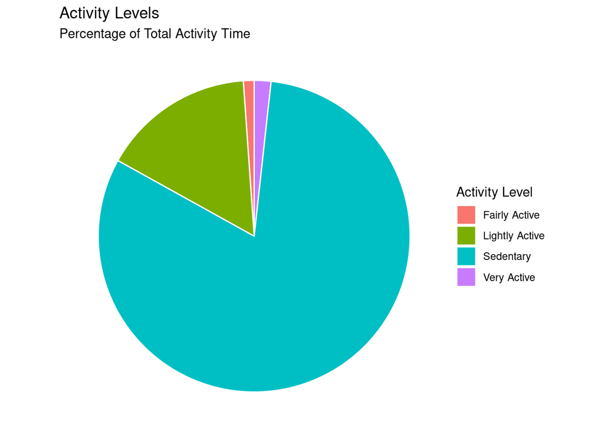

```r
# Pie chart showing the breakdown of active minutes by activity level

# calculate the percentage of activity levels
activity_levels <- c(sum(daily_activity_cleaned$very_active_minutes),
                     sum(daily_activity_cleaned$fairly_active_minutes),
                     sum(daily_activity_cleaned$lightly_active_minutes),
                     sum(daily_activity_cleaned$sedentary_minutes))
activity_percentages <- activity_levels / sum(activity_levels) * 100

# create a data frame for the pie chart
activity_data <- data.frame(activity = c("Very Active", "Fairly Active", "Lightly Active", "Sedentary"),
                            percentage = activity_percentages)

# create the pie chart
ggplot(activity_data, aes(x="", y=percentage, fill=activity)) +
  geom_bar(width = 1, stat = "identity", color = "white") +
  coord_polar(theta = "y") +
  theme_void() +
  labs(title = "Activity Levels",
       subtitle = "Percentage of Total Activity Time",
       fill = "Activity Level")
```